# Identification

| a |
| --- |
| title: “Reproducible Research: Peer Assessment 1” |
| author: “Carlos Tangarife” |
| date: “Sunday, April 19, 2015” |

# General information

| File | Output | Source data |
| --- | --- | --- |
| PA_template.Rmd | html_document | activity.csv |

## Dataset description.

This assignment makes use of data from a personal activity monitoring device. This device collects data at 5 minute intervals through out the day. The data consists of two months of data from an anonymous individual collected during the months of October and November, 2012 and include the number of steps taken in 5 minute intervals each day.

# Loading & Preprocessing Data

I will download the dataset required for this assignment.

First show Code that is needed to:

1. Load the data
2. Process/transform the data

Remove all variables from the Global Environment and load data

```r
# Load the plotting package `ggplot2.
# Try to install the package if it isn't found.
if(!suppressMessages(require(ggplot2))){
    print('trying to install ggplot2')
    install.packages('ggplot2')
    if(suppressMessagesrequire(ggplot2)){
        print("ggplot2 installed and loaded")
    } else {
        stop("could not install ggplot2")
    }
}
rm(list=ls(all=TRUE))
# suppress warnings
ass1Data <- read.csv('activity.csv', stringsAsFactors = FALSE)
#read.csv("activity.csv")
```

Show head and convert date

```r
head(ass1Data)
```

```
##   steps       date interval
## 1    NA 2012-10-01        0
## 2    NA 2012-10-01        5
## 3    NA 2012-10-01       10
## 4    NA 2012-10-01       15
## 5    NA 2012-10-01       20
## 6    NA 2012-10-01       25
```

```r
# convert date to date data type
ass1Data$date <- as.Date(ass1Data$date)
#Create a new dataset ignoring missing data NA
ass1DataIgnoreNa <- na.omit(ass1Data)
```

sum steps by date

```r
dailySteps <-aggregate(formula = steps~date, data = ass1Data, FUN = sum, na.rm=TRUE)
```

Plot histogram

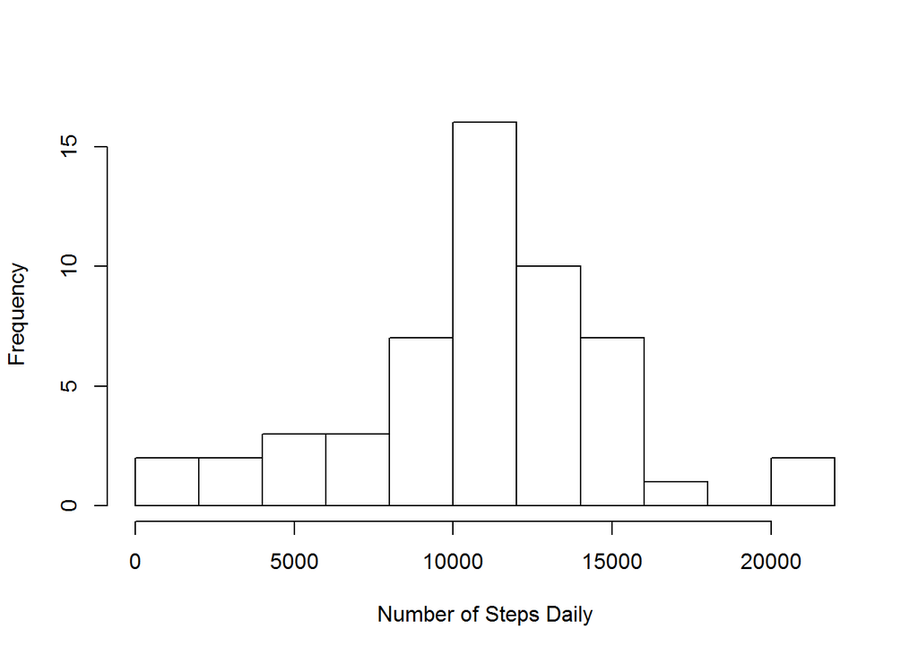

```r
hist(dailySteps$steps, main=" ", breaks=10,xlab="Number of Steps Daily")
```

I continue with the analysis as requested.

# What is mean total number of steps taken per day?

Report mean and median of the total number of steps taken per day:

```r
round(mean(dailySteps$steps))
```

```
## [1] 10766
```

```r
median(dailySteps$steps)
```

```
## [1] 10765
```

# What is the average daily activity pattern?

Calculate the average steps an make a time series plot (i.e. type = “l”) of the 5-minute interval (x-axis) and the average number of steps taken, averaged across all days (y-axis)

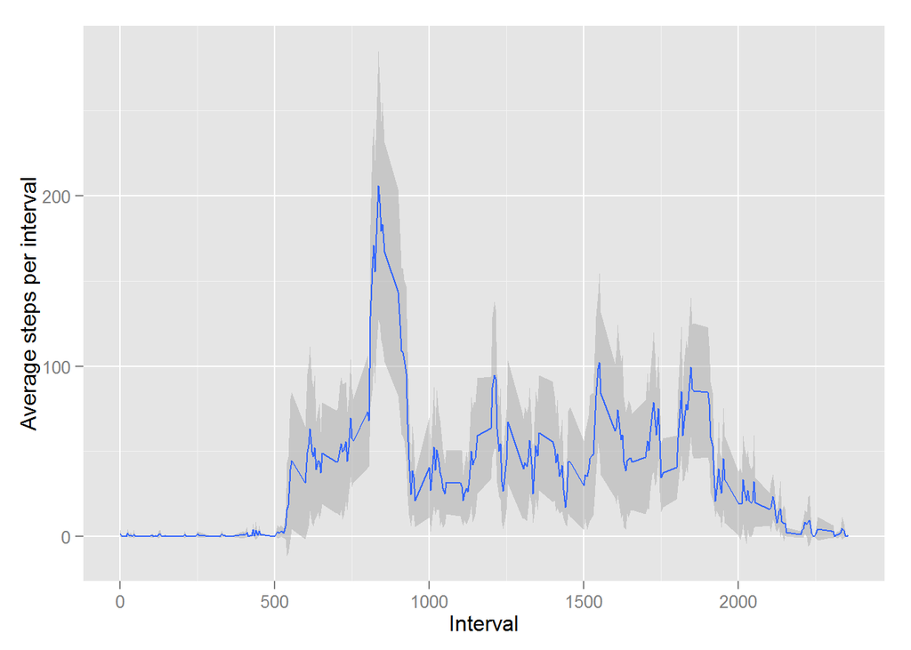

```r
intervalActivity <- aggregate(formula=steps~interval, data=ass1Data, FUN=mean, na.rm=TRUE)
maxSteps <- intervalActivity[which(intervalActivity$steps==max(intervalActivity$steps)),]
# Get the data for the interval with the most average activity across the days


mean_ci <- function(data)
{
    m <- mean(data)
    data.frame(y=m,
               ymin = m-(1.96*sd(data)/sqrt(length(data))),
               ymax = m+(1.96*sd(data)/sqrt(length(data))))
}


# Plot the average number of steps per interval.
# Use ggplot2 to summarize de data, to
# find inconsistencies with the analysis.
# Geom 'line' is equivalent to 'type="l"' in plot.
stepsInterval <-
qplot(x=interval, y=steps,
      data=subset(ass1Data, complete.cases(ass1Data)),
      geom='smooth', stat='summary', fun.data=mean_ci) +
  labs(y='Average steps per interval', x='Interval')

stepsInterval
```

Report the 5-min interval, on average across all the days in the dataset, contains the maximum number of steps:

```r
max_steps <- intervalActivity[which(intervalActivity$steps==max(intervalActivity$steps)),]
max_steps
```

```
##     interval    steps
## 104      835 206.1698
```

```r
#intervalMeanSteps[which.max(intervalMeanSteps$mean), ]
```

Result:

The person’s daily activity interval around 8:35 am contains the maximun number of steps.

# Imputing missing values

In this section:

```r
# Count the number of NAs
totalNAs <- sum(!complete.cases(ass1Data))
stepNAs <- sum(is.na(ass1Data$steps))

# Calculate the number of missing dates
datesInRange <- seq.Date(from = min(ass1Data$date),
                           to = max(ass1Data$date),
                           by='1 day')
dateNAs <- sum(!ass1Data$date[complete.cases(ass1Data)] %in% datesInRange)
```

Second Implement a strategy for filling in all of the missing values in the dataset.

[figure not shown]

```r
# Use previously calculated means
intervalActivity$imputedSteps <- floor(intervalActivity$steps)

# Merge the replacement values
imputedActivity <- merge(ass1Data,
                          intervalActivity[,c('interval', 'imputedSteps')],
                          by='interval')

# Replace the missing values
imputedActivity$steps <- ifelse(is.na(imputedActivity$steps),
                                 imputedActivity$imputedSteps,
                                 imputedActivity$steps)

# Remove unnecesary data
imputedActivity$imputedSteps <- NULL


#Plot histogram after imputation
hist(dailySteps$steps,
main=" ",
breaks=10,
xlab="Total Number of Steps Taken Daily After Imputation")
```

```r
# Summarize the data by day
dailyImpActivity <-
  aggregate(formula = steps~date, data = imputedActivity,
            FUN = sum, na.rm=TRUE)
```

Calculate and report the mean and median total number of steps taken per day.

```r
# Calculate summary statistics
meanImpSteps <- round(mean(dailyImpActivity$steps), 2)
meanImpSteps
```

```
## [1] 10749.77
```

```r
medianImpSteps <- round(median(dailyImpActivity$steps),2)
medianImpSteps
```

```
## [1] 10641
```

[figure not shown]

```r
# Plot histogram imput values

hist(dailyImpActivity$steps,
main=" ",
breaks=10,
xlab="Total Number of Steps Taken Daily Before Imputation")
```

# Differences in activity patterns between weekdays and weekends?

- Use the dataset with the filled-in missing values for this part. Create a new factor variable in the dataset with two levels - “weekday” and “weekend” indicating whether a given date is a weekday or weekend day.
- Make a panel plot containing a time series plot (i.e. type = “l”) of the 5-minute interval (x-axis) and the average number of steps taken, averaged across all weekday days or weekend days (y-axis).

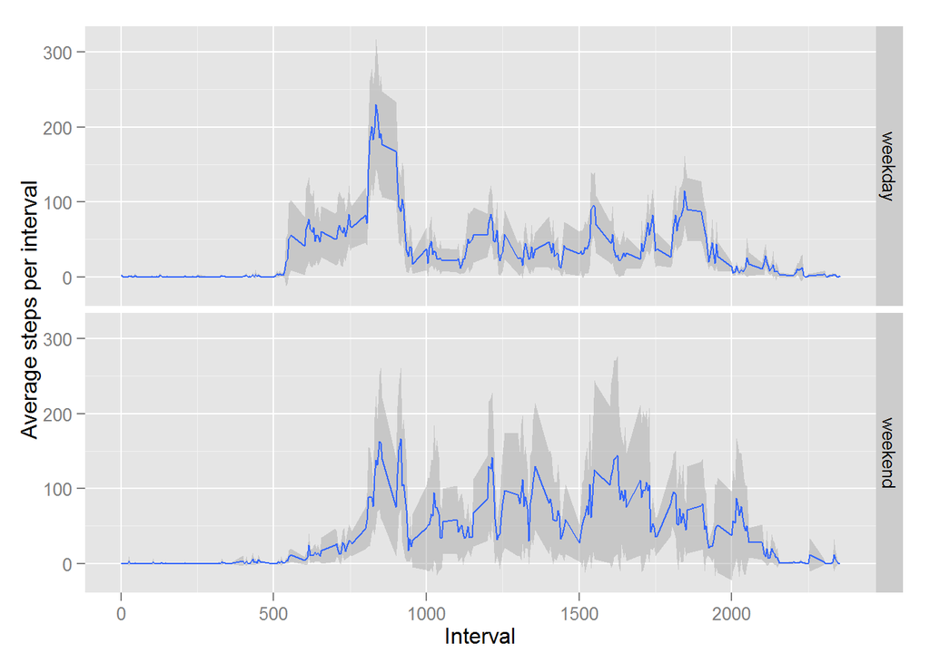

```r
# Label each date as weekday/weekend (1:5 are weekdays, 6:7 are weekends)
imputedActivity$weekPart <- factor(
  ifelse(as.integer(format(imputedActivity$date, format = '%u')) %in% c(1:5),
         'weekday', 'weekend'))

# Plot the average steps per interval, given the week_part
stepsInterval %+% imputedActivity + facet_grid(weekPart~.)
```

```r
# Make a panel plot containing a time series plot (i.e. type = "l") of the 5-minute interval (x-axis) and the average number of steps taken, averaged across all weekday days or weekend days (y-axis).
#
```

Final report:

Are there differences in activity patterns between weekdays and weekends? Yes. The plot indicates that the person moves around more (or more active) during the weekend days.

# Conclusion

In this assignment, it provided a approach for analyzing data. The data analysis started from loading data, transform data including the strategy and implementation of dealing with missing data, and reporting statistical data and plots. The reader should be able to follow the document and reproduce the same results.

The document was prepared with R Studio Version 0.98.1073

**Note:** tools used: R, R-studio, GitHub, Knitr, and RMarkdown.